# Lab Assignment 3: Extending Logistic Regression

### Jaime Garcia, Arefeh Safaei Moghadam, Jase Sitton

## 1. Preparation and Overview

### 1.1. Business Understanding

The thyroid is a gland in the human body that is responsible for, among other things, governing how fast calories are burned and regulating heart rate. It accomplishes this by producing a hormone called thyroid hormone. Various thyroid diseases may cause the thyroid to produce either too much thyroid hormone (hyperthyroidism) or not enough hormone (hypothyroidism), which may result in feeling restless or cause weight fluctuations. Women are more susceptible than men to thyroid diseases.

While the symptoms of hyperthyroidism and hypothyroidism are not particularly severe, if left untreated, they may evolve into rare but potentially fatal conditions. Hyperthyroidism and hypothyroidism can usually be diagnosed through blood tests. The blood tests used to diagnose thyroid conditions include:

- Thyroid-stimulating hormone (TSH), a chemical released by the pituary gland that stimulates the thyroid to produce thyroid hormone
- Triiodothyronine (T3), a hormone produced directly by the thyroid
- Thyroxine, the primary hormone produced by the thyroid, which comes in two forms (free T4 and bound T4) and may be measured using different blood tests including:
  - Total T4 (TT4), which measures both free T4 and bound T4
  - T4 uptake (T4U), which measures how much radioactive iodine is taken up by the thyroid
  - Free thyroxine index (FTI), another measure of free thyroxine
- Thyroxine-binding globulin (TBG), a protein that most of the protein-bound T3 and T4 in the blood bind to

The UCI Thyroid Disease Data Set contains results from the above blood tests as well as other true/false queries about current patient condition, symptoms, and medication. Data for thousands of patients was collected. A total of 30 features along with a classification are provided for each patient. A total of 9 classifications of thyroid condition are considered.

This model would act as a first-pass screening tool for doctors to use when interviewing patients with potential thyroid conditions. The goal is to use blood test results and patient history questions to rapidly diagnose hyperthyroidism and hypothyroidsm. While an automated diagnosis system will never replace a trained doctor, it may be a valuable tool in a doctor's belt to aid the doctor in quickly arriving at the correct diagnosis. Diagnosing hyperthyroidsm and hypothyroidism may not always be straightforward due to the common nature of the symptoms; often a combination of the patient history as well as the previously-discussed blood tests. Saving any amount of time in diagnosing a patient with a thyroid condition provides the patient with additional time to seek proper treatment before a more serious condition develops.

For this model to be useful, it should be able to aid doctors in more accurately diagnosing thyroid conditions. The specific accuracy necessary for the model is difficult to estimate, however the accuracy should be high enough that the combination of the model with traditional diagnosis method performed by a medical professional has a higher diagnosis accuracy than doctors independently without the model. The model may be tuned to account for trends in the diagnoses of human doctors; in other words, if doctors are prone to false negatives (a negative diagnosis when the patient actually has a thyroid condition), the model may be tuned such that it is more prone to false positives. In this way, the strengths of the model may be tuned to complement the strengths of the doctors.

This model would be used for offline analysis only whereby the doctor or lab technician using it would plug in data from a given patient to obtain a result from the model. Model updating and training would occur on a regular basis depending on the availability of new samples. If new samples are frequent, *i.e.* the model is used by an institution with a high number of patients receiving thyroid tests, then training may be performed relatively frequently (perhaps weekly); if new training samples are infrequent, then monthly retraining may be more appropriate. Optimization of training time is not a priority; for this model, it is better to take a long time training and be as accurate as possible than to optimize training time at the expense of accuracy.

### 1.2. Dataset Preparation and Description

```python
import pandas as pd
import numpy as np
from numpy.random import rand
from sklearn.preprocessing import OneHotEncoder

# load the two datasets
df_hypo = pd.read_csv(r'all_hypo.csv')
df_hyper = pd.read_csv(r'all_hyper.csv')

# rename some columns
df_hypo.rename(columns = {'ID' : 'hypo_ID', 'class' : 'hypo_class'}, inplace=True)
df_hyper.rename(columns = {'ID' : 'hyper_ID', 'class' : 'hyper_class'}, inplace=True)

# merge datasets based on patient ID numbers
df = pd.merge(df_hypo, df_hyper[['hyper_ID', 'hyper_class']], left_on='hypo_ID', right_on='hyper_ID', how='right')

# replace the labels with integer classes:
#    0 - 'negative', indicating no thyroid condition
#    1 - 'hypothyroid', indicating a hypothyroidism condition
#    2 - 'hyperthyroid', indicating a hyperthyroidism condition
labels = ['hypothyroid.', 'primary hypothyroid.', 'compensated hypothyroid.'
          ,'secondary hypothyroid.', 'hyperthyroid.', 'T3 toxic.', 'goitre.', 'secondary toxic.','negative.']
classes = [1,1,1,1,2,2,2,2,0]
df = df.replace(labels , classes)

# decide the class of each patient
df['class'] = df[['hypo_class' , 'hyper_class']].apply(np.max , axis=1)

# remove obsolete columns
del_cols = ['hyper_ID', 'hyper_class', 'hypo_class', 'query_hypothyroid', 'query_hyperthyroid', 'TSH_measured', \
            'T3_measured', 'TT4_measured', 'T4U_measured', 'FTI_measured' ,  'TBG_measured' , 'referral_source', 'TBG']

for col in del_cols:
    if col in df:
        del df[col]

df.rename(columns={'hypo_ID' : 'ID'}, inplace=True)

# replace '?' with 'NaN' and t/f with binary
df = df.replace({'?' : np.nan,
                 'f' : 0, 't' : 1,
                 'F' : 0, 'M' : 1})

# get rid of samples with 'NaN' values
df.dropna(subset=['Age', 'Sex', 'T3', 'TSH', 'FTI', 'T4U', 'TT4'], how='any', inplace=True)

# change data type for continuous variables to 'float' and change data type for 'Age' to 'int'
continuous = ['TSH', 'T3', 'TT4', 'T4U', 'FTI']
df[continuous] = df[continuous].astype(np.float64)
df['Age'] = df['Age'].astype(np.int64)

# remove outliers
df = df[df['Age'] < 100]
df = df[df['TSH'] < 200]
df = df[df['TT4'] < 400]
df = df[df['FTI'] < 300]

df.info()
```

```
<class 'pandas.core.frame.DataFrame'>
Int64Index: 1942 entries, 0 to 2799
Data columns (total 21 columns):
Age                   1942 non-null int64
Sex                   1942 non-null float64
on_thyroxine          1942 non-null int64
query_on_thyroxine    1942 non-null int64
on_antithyroid_med    1942 non-null int64
sick                  1942 non-null int64
pregnant              1942 non-null int64
surgery               1942 non-null int64
I131_treatment        1942 non-null int64
lithium               1942 non-null int64
goitre                1942 non-null int64
tumor                 1942 non-null int64
hypopituitary         1942 non-null int64
psych                 1942 non-null int64
TSH                   1942 non-null float64
T3                    1942 non-null float64
TT4                   1942 non-null float64
T4U                   1942 non-null float64
FTI                   1942 non-null float64
ID                    1942 non-null int64
class                 1942 non-null int64
dtypes: float64(6), int64(15)
memory usage: 333.8 KB
```

```python
# data description table
data = [['ID', 'Patient ID number', 'nominal', 'discrete', '1-2800'],
        ['Age', 'Patient Age', 'ordinal', 'discrete', '1 - 94'],
        ['Sex', 'Patient Sex', 'nominal', 'discrete', '0 : female | 1 : male'],
        ['query_on_thyroxine', 'Is the patient on thyroxine medication?', 'nominal', 'discrete', '0 : false | 1 : true'],
        ['on_antithyroid_med', 'Is the patient on antithyroid medication?', 'nominal', 'discrete', '0 : false | 1 : true'],
        ['sick', 'Is the patient currently sick?', 'nominal', 'discrete', '0 : false | 1 : true'],
        ['surgery', 'Has the patient had any surgeries?', 'nominal', 'discrete', '0 : false | 1 : true'],
        ['I131_treatment', 'Has the patient received Iodine-131 treatment?', 'nominal', 'discrete', '0 : false | 1 : true'],
        ['lithium', 'Is the patient on lithium medication?', 'nominal', 'discrete', '0 : false | 1 : true'],
        ['goitre', 'Is the patient exhibiting goitre?', 'nominal', 'discrete', '0 : false | 1 : true'],
        ['tumor', 'Does the patient have a tumor?', 'nominal', 'discrete', '0 : false | 1 : true'],
        ['hypopituitary', 'Does the patient have hypopituitarism?', 'nominal', 'discrete', '0 : false | 1 : true'],
        ['psych', 'Does the patient have any psychiatric disorders?', 'nominal', 'discrete', '0 : false | 1 : true'],
        ['pregnant', 'Is the patient pregnant?', 'nominal', 'discrete', '0 : false | 1 : true'],
        ['TSH', "Patient's TSH level", 'ratio', 'continuous', '0.0 - 0.53'],
        ['T3', "Patient's T3 level", 'ratio', 'continuous', '0.0005 - 0.18'],
        ['TT4', "Patient's TT4 level", 'ratio', 'continuous', '0.002 - 0.6'],
        ['T4U', "Patient's T4U level", 'ratio', 'continuous', '0.017 - 0.233'],
        ['FTI', "Patient's FTI level", 'ratio', 'continuous', '0.002 - 0.642'],
        ['class', 'Patient diagnosis', 'nominal', 'categorical', '0 - 2']]

data_des = pd.DataFrame(data, columns = ['Features', 'Description', 'Scale', 'Data Type', 'Range'])
data_des
```

|  | Features | Description | Scale | Data Type | Range |
| --- | --- | --- | --- | --- | --- |
| 0 | ID | Patient ID number | nominal | discrete | 1-2800 |
| 1 | Age | Patient Age | ordinal | discrete | 1 - 94 |
| 2 | Sex | Patient Sex | nominal | discrete | 0 : female \| 1 : male |
| 3 | query_on_thyroxine | Is the patient on thyroxine medication? | nominal | discrete | 0 : false \| 1 : true |
| 4 | on_antithyroid_med | Is the patient on antithyroid medication? | nominal | discrete | 0 : false \| 1 : true |
| 5 | sick | Is the patient currently sick? | nominal | discrete | 0 : false \| 1 : true |
| 6 | surgery | Has the patient had any surgeries? | nominal | discrete | 0 : false \| 1 : true |
| 7 | I131_treatment | Has the patient received Iodine-131 treatment? | nominal | discrete | 0 : false \| 1 : true |
| 8 | lithium | Is the patient on lithium medication? | nominal | discrete | 0 : false \| 1 : true |
| 9 | goitre | Is the patient exhibiting goitre? | nominal | discrete | 0 : false \| 1 : true |
| 10 | tumor | Does the patient have a tumor? | nominal | discrete | 0 : false \| 1 : true |
| 11 | hypopituitary | Does the patient have hypopituitarism? | nominal | discrete | 0 : false \| 1 : true |
| 12 | psych | Does the patient have any psychiatric disorders? | nominal | discrete | 0 : false \| 1 : true |
| 13 | pregnant | Is the patient pregnant? | nominal | discrete | 0 : false \| 1 : true |
| 14 | TSH | Patient's TSH level | ratio | continuous | 0.0 - 0.53 |
| 15 | T3 | Patient's T3 level | ratio | continuous | 0.0005 - 0.18 |
| 16 | TT4 | Patient's TT4 level | ratio | continuous | 0.002 - 0.6 |
| 17 | T4U | Patient's T4U level | ratio | continuous | 0.017 - 0.233 |
| 18 | FTI | Patient's FTI level | ratio | continuous | 0.002 - 0.642 |
| 19 | class | Patient diagnosis | nominal | categorical | 0 - 2 |

### 1.3. Data Division

```python
from sklearn.model_selection import train_test_split
from sklearn.model_selection import StratifiedShuffleSplit

X = df.drop(['ID', 'class'], axis=1).values
y = df['class'].values

sss = StratifiedShuffleSplit(n_splits=10, test_size=0.20, random_state=0)
for train_index, test_index in sss.split(X, y):
    X_train, X_test = X[train_index], X[test_index]
    y_train, y_test = y[train_index], y[test_index]

print('Number of training samples: {}'.format(X_train.shape[0]))
print('Number of training labels:  {}'.format(y_train.shape[0]))
print('Number of testing samples:  {}'.format(X_test.shape[0]))
print('Number of testing labels:   {}'.format(y_test.shape[0]))
```

```
Number of training samples: 1553
Number of training labels:  1553
Number of testing samples:  389
Number of testing labels:   389
```

To investigate whether an 80% training and 20% testing split is appropriate for this dataset, a class frequency plot was created to show the training/testing split by class. The training and testing counts by class have also been tabulated.

```python
import matplotlib.pyplot as plt

plt.figure(figsize=(10,8))
unique_train, counts_train = np.unique(y_train, return_counts=True)
plt.bar(unique_train, counts_train)
unique_test, counts_test = np.unique(y_test, return_counts=True)
plt.bar(unique_test, counts_test)
plt.xticks((0, 1, 2))
plt.title('Class Frequency', fontsize=20)
plt.xlabel('Class', fontsize=14)
plt.ylabel('Number of Samples', fontsize=14)
plt.legend(['Training [%i samples]' % y_train.shape[0], 'Testing [%i samples]' % y_test.shape[0]], fontsize=12)
plt.show()
```

[output not shown]

Both the training and testing datasets contain many more samples of class 0 than of either classes 1 or 2; there is an order of magnitude difference between the counts for class 0 and the counts for class 1, which has the next highest number of samples. The 80/20 split is not the cause of this; rather, it is a function of the class breakdown within the full dataset. A concern in this situation is that any model trained on this set will learn that predicting class 0 for every input will yield relatively high performance. One solution is to assign higher weighting to samples in classes 1 and 2 during the training process. Another solution would be to exclude some samples that are class 0 to obtain more parity within the training and testing datasets.

As far as the training/testing split is concerned, class 2 is the limiting factor. With an 80/20 split, there are only 44 samples for training and 12 samples for testing. It is hard to say whether 44 samples will be enough to adequately train a model to predict class 2; thus, if anything, the training/testing split should be moved to favor training dataset size even more. Perhaps a split of 85/15 or 90/10 would work better.

To rectify the class imbalance, two techniques will be used:

1. Undersampling the majority class (class 0)
2. Oversampling the minority classes (classes 1 and 2)

Typically, only one of these techniques would be used; however, in this dataset the class imbalance is so significant and the minority classes have so few samples that it was decided to try and have the classes "meet in the middle", so to speak. The majority class was randomly undersampled so that 600 samples remained after the undersampling.

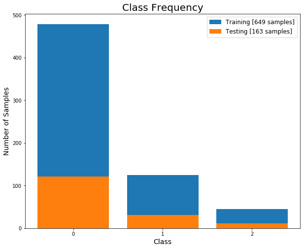

```python
from imblearn.under_sampling import RandomUnderSampler

X_raw = X
y_raw = y

us = RandomUnderSampler(random_state=42, sampling_strategy={0 : 600})
X, y = us.fit_resample(X, y)

for train_index, test_index in sss.split(X, y):
    X_train, X_test = X[train_index], X[test_index]
    y_train, y_test = y[train_index], y[test_index]

plt.figure(figsize=(10,8))
unique_train, counts_train = np.unique(y_train, return_counts=True)
plt.bar(unique_train, counts_train)
unique_test, counts_test = np.unique(y_test, return_counts=True)
plt.bar(unique_test, counts_test)
plt.xticks((0, 1, 2))
plt.title('Class Frequency', fontsize=20)
plt.xlabel('Class', fontsize=14)
plt.ylabel('Number of Samples', fontsize=14)
plt.legend(['Training [%i samples]' % y_train.shape[0], 'Testing [%i samples]' % y_test.shape[0]], fontsize=12)
plt.show()
```

After the undersampling process, the SMOTE (Synthetic Minority Over-sampling Technique) algorithm was used to oversample the minority classes. The specific implementation of SMOTE used was `SMOTENC` from the `imblearn` library, which is a SMOTE implementation for datasets containing continuous and categorical features. SMOTE creates "synthetic" examples of the minority classes which are added to the pre-existing samples using a *k* nearest neighbors approach; no replacement is performed. More details on the algorithm can be found in [1], where the algorithm was first introduced.

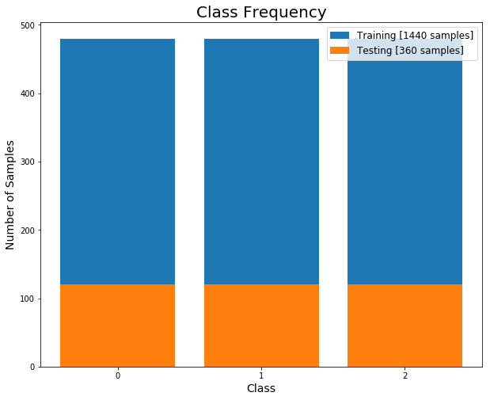

```python
from imblearn.over_sampling import SMOTENC

sm = SMOTENC(random_state=42, categorical_features=[0, 1, 2, 3, 4, 5, 6, 7, 8, 9, 10, 11, 12, 13])
X, y = sm.fit_resample(X, y)

for train_index, test_index in sss.split(X, y):
    X_train, X_test = X[train_index], X[test_index]
    y_train, y_test = y[train_index], y[test_index]

plt.figure(figsize=(10,8))
unique_train, counts_train = np.unique(y_train, return_counts=True)
plt.bar(unique_train, counts_train)
unique_test, counts_test = np.unique(y_test, return_counts=True)
plt.bar(unique_test, counts_test)
plt.xticks((0, 1, 2))
plt.title('Class Frequency', fontsize=20)
plt.xlabel('Class', fontsize=14)
plt.ylabel('Number of Samples', fontsize=14)
plt.legend(['Training [%i samples]' % y_train.shape[0], 'Testing [%i samples]' % y_test.shape[0]], fontsize=12)
plt.show()
```

## 2. Modeling

```python
class BinaryLogisticRegression:
    def __init__(self, eta, iterations=20, regularization="L2" , C=0.001, w0='zeros'):
        self.eta = eta
        self.iters = iterations
        self.C = C
        self.reg = regularization
        self.w0 = w0
        # internally we will store the weights as self.w_ to keep with sklearn conventions

    def __str__(self):
        if(hasattr(self, 'w_')):
            return 'Binary Logistic Regression Object with coefficients:\n'+ str(self.w_) # is we have trained the object
        else:
            return 'Untrained Binary Logistic Regression Object'

    # convenience, private:
    @staticmethod
    def _add_bias(X):
        return np.hstack((np.ones((X.shape[0],1)), X)) # add bias term

    @staticmethod
    def _sigmoid(theta):
        # increase stability, redefine sigmoid operation
        return expit(theta) #1/(1+np.exp(-theta))

    # vectorized gradient calculation with regularization using L2 Norm
    def _get_gradient(self, X, y):
        ydiff = y-self.predict_proba(X, add_bias=False).ravel() # get y difference
        gradient = np.mean(X * ydiff[:,np.newaxis], axis=0) # make ydiff a column vector and multiply through

        gradient = gradient.reshape(self.w_.shape)

        #Applying Reguarization Penalty

        #if Ridge
        if self.reg == "L2":
            gradient[1:] += -2 * self.w_[1:] * self.C
        #if LASSO
        elif self.reg == "L1":
            gradient[1:] += -1 * np.sign(self.w_[1:]) * self.C
        #if Elastic Net
        elif self.reg == "ElasticNet":
            gradient[1:] += -self.C * ((2*self.w_[1:]) + (np.sign(self.w_[1:])) )

        return gradient

    # public:
    def predict_proba(self, X, add_bias=True):
        # add bias term if requested
        Xb = self._add_bias(X) if add_bias else X
        return self._sigmoid(Xb @ self.w_) # return the probability y=1

    def predict(self, X):
        return (self.predict_proba(X) > 0.5) #return the actual prediction

    def fit(self, X, y):
        Xb = self._add_bias(X) # add bias term
        num_samples, num_features = Xb.shape

        if self.w0 == 'random':
            self.w_ = rand(num_features,1)
        else:
            self.w_ = np.zeros((num_features,1)) # init weight vector to zeros

        # for as many as the max iterations
        for _ in range(self.iters):
            gradient = self._get_gradient(Xb, y)
            self.w_ += gradient*self.eta # multiply by learning rate
            # add bacause maximizing

blr = BinaryLogisticRegression(eta=0.1, iterations=500, C=0.001)
print(blr)
```

```
Untrained Binary Logistic Regression Object
```

```python
from scipy.optimize import minimize_scalar
from scipy.special import expit
import copy
class LineSearchLogisticRegression(BinaryLogisticRegression):

    # define custom line search for problem
    @staticmethod
    def objective_function(eta, X, y, w, grad, C):
        wnew = w - grad*eta
        g = expit(X @ wnew)
        return -np.sum(np.log(g[y==1]))-np.sum(np.log(1-g[y==0])) + C*sum(wnew**2)

    def fit(self, X, y):
        Xb = self._add_bias(X) # add bias term
        num_samples, num_features = Xb.shape

        self.w_ = np.zeros((num_features,1)) # init weight vector to zeros

        # for as many as the max iterations
        for _ in range(self.iters):
            gradient = -self._get_gradient(Xb,y)
            # minimization inopposite direction

            # do line search in gradient direction, using scipy function
            opts = {'maxiter':self.iters/50} # unclear exactly what this should be
            res = minimize_scalar(self.objective_function, # objective function to optimize
                                  bounds=(self.eta/1000,self.eta*10), #bounds to optimize
                                  args=(Xb, y, self.w_, gradient, self.C), # additional argument for objective function
                                  method='bounded', # bounded optimization for speed
                                  options=opts) # set max iterations

            eta = res.x # get optimal learning rate
            self.w_ -= gradient*eta # set new function values
            # subtract to minimize

lslr = LineSearchLogisticRegression(eta=0.01, iterations=40, C=0.001)
print(lslr)
```

```
Untrained Binary Logistic Regression Object
```

```python
class StochasticLogisticRegression(BinaryLogisticRegression):
    # stochastic gradient calculation
    def _get_gradient(self,X,y):
        idx = int(np.random.rand()*len(y)) # grab random instance
        ydiff = y[idx]-self.predict_proba(X[idx],add_bias=False) # get y difference (now scalar)
        gradient = X[idx] * ydiff[:,np.newaxis] # make ydiff a column vector and multiply through

        gradient = gradient.reshape(self.w_.shape)
        #### change it here
        if self.reg == "L2":
            gradient[1:] += -2 * self.w_[1:] * self.C
        #if LASSO
        elif self.reg == "L1":
            gradient[1:] += -1 * np.sign(self.w_[1:]) * self.C
        #if Elastic Net
        elif self.reg == "ElasticNet":
            gradient[1:] += -self.C * ((2*self.w_[1:]) + (np.sign(self.w_[1:])) )

        return gradient

slr = StochasticLogisticRegression(0.05, 500, C=0.001) # take a lot more steps!!
print(slr)
```

```
Untrained Binary Logistic Regression Object
```

```python
from numpy.linalg import pinv
class HessianBinaryLogisticRegression(BinaryLogisticRegression):
    # just overwrite gradient function
    def _get_gradient(self, X, y):
        g = self.predict_proba(X, add_bias=False).ravel() # get sigmoid value for all classes
        hessian = X.T @ np.diag(g*(1-g)) @ X - 2 * self.C # calculate the hessian

        ydiff = y-g # get y difference
        gradient = np.sum(X * ydiff[:,np.newaxis], axis=0) # make ydiff a column vector and multiply through
        gradient = gradient.reshape(self.w_.shape)

        ###Change it here
        if self.reg == "L2":
            gradient[1:] += -2 * self.w_[1:] * self.C
        elif self.reg == "L1":
            gradient[1:] += -1 * np.sign(self.w_[1:]) * self.C
        elif self.reg == "ElasticNet":
            gradient[1:] += -self.C * ((2*self.w_[1:]) + (np.sign(self.w_[1:])) )

        return pinv(hessian) @ gradient

hlr = HessianBinaryLogisticRegression(eta=1.0, iterations=5, C=0.001) # note that we need only a few iterations here
print(hlr)
```

```
Untrained Binary Logistic Regression Object
```

```python
class LogisticRegression:
    def __init__(self, eta=0.001, iterations=20, regularization = "L2" , C=0.001, solver='SteepDes', w0='zeros'):
        self.eta = eta
        self.iters = iterations
        self.solver = solver
        self.C = C
        self.reg = regularization
        self.w0 = w0
        # internally we will store the weights as self.w_ to keep with sklearn conventions

    def __str__(self):
        if(hasattr(self,'w_')):
            return 'MultiClass Logistic Regression Object with coefficients:\n'+ str(self.w_) # is we have trained the object
        else:
            return 'Untrained MultiClass Logistic Regression Object'

    # from the sklearn API, necessary to use grid search for hyperparameter optimization via sklearn
    # https://scikit-learn.org/stable/developers/contributing.html#get-params-and-set-params
    def get_params(self, deep=True):
        # suppose this estimator has parameters "alpha" and "recursive"
        return {"eta": self.eta, "iterations" : self.iters, "C" : self.C, "solver" : self.solver, "regularization" : self.reg}

    def set_params(self, **parameters):
        for parameter, value in parameters.items():
            setattr(self, parameter, value)
        return self

    def fit(self, X, y):
        num_samples, num_features = X.shape
        self.unique_ = np.unique(y) # get each unique class value
        num_unique_classes = len(self.unique_)
        self.classifiers_ = [] # will fill this array with binary classifiers

        for i, yval in enumerate(self.unique_): # for each unique value
            y_binary = (y==yval) # create a binary problem
            # train the binary classifier for this class
            if self.solver == 'SteepestDes':
                blr = LineSearchLogisticRegression(self.eta, self.iters, self.reg, self.C)
            elif self.solver == 'SGD':
                blr = StochasticLogisticRegression(self.eta, self.iters, self.reg, self.C)
            elif self.solver == 'Newton':
                blr = HessianBinaryLogisticRegression(self.eta, self.iters, self.reg, self.C)
            elif self.solver == 'NewtonMSE':
                blr = HessianBinaryLogisticRegressionMSE(self.eta, self.iters, self.reg, self.C, self.w0)
            blr.fit(X, y_binary)
            # add the trained classifier to the list
            self.classifiers_.append(blr)

        # save all the weights into one matrix, separate column for each class
        self.w_ = np.hstack([x.w_ for x in self.classifiers_]).T

    def predict_proba(self, X):
        probs = []
        for blr in self.classifiers_:
            probs.append(blr.predict_proba(X)) # get probability for each classifier

        return np.hstack(probs) # make into single matrix

    def predict(self, X):
        return np.argmax(self.predict_proba(X), axis=1) # take argmax along row
```

With all of the necessary classes set up, a randomized grid search will be used to optimize the hyperparameters for the logistic regression model.

```python
%%time
from sklearn.model_selection import RandomizedSearchCV
from numpy.random import uniform
from numpy.random import randint

n_iters = 1000
param_grid = {'eta' : uniform(0.0001, 0.1001, size=100),
              'iterations' : randint(5, 2001, size=1000),
              'C' : uniform(0.0001, 0.0101, size=100),
              'solver' : ['SteepestDes', 'SGD', 'Newton'],
              'regularization' : ['L1', 'L2', 'ElasticNet', 'None']}

lr = LogisticRegression()

random_search = RandomizedSearchCV(lr, param_distributions=param_grid, n_iter=n_iters, cv=sss, iid=False, scoring='accuracy',
                                   return_train_score=False, verbose=1)
rs = random_search.fit(X, y)
```

```
Fitting 10 folds for each of 1000 candidates, totalling 10000 fits
```

```
[Parallel(n_jobs=1)]: Using backend SequentialBackend with 1 concurrent workers.
[Parallel(n_jobs=1)]: Done 10000 out of 10000 | elapsed: 30.9min finished
```

```
Wall time: 30min 53s
```

```python
df_rs = pd.DataFrame(rs.cv_results_)
df_rs
```

|  | mean_fit_time | std_fit_time | mean_score_time | std_score_time | param_solver | param_regularization | param_iterations | param_eta | param_C | params | ... | split3_test_score | split4_test_score | split5_test_score | split6_test_score | split7_test_score | split8_test_score | split9_test_score | mean_test_score | std_test_score | rank_test_score |
| --- | --- | --- | --- | --- | --- | --- | --- | --- | --- | --- | --- | --- | --- | --- | --- | --- | --- | --- | --- | --- | --- |
| 0 | 0.046805 | 7.705321e-03 | 0.0003 | 0.000458 | SteepestDes | None | 777 | 0.00866951 | 0.00645353 | {'solver': 'SteepestDes', 'regularization': 'N... | ... | 0.394444 | 0.402778 | 0.525000 | 0.444444 | 0.375000 | 0.413889 | 0.386111 | 0.415278 | 0.047243 | 735 |
| 1 | 0.050005 | 3.847455e-03 | 0.0003 | 0.000458 | SteepestDes | L2 | 1191 | 0.0354795 | 0.00597192 | {'solver': 'SteepestDes', 'regularization': 'L... | ... | 0.427778 | 0.477778 | 0.400000 | 0.550000 | 0.511111 | 0.486111 | 0.413889 | 0.475278 | 0.057446 | 471 |
| 2 | 0.482948 | 1.182021e-02 | 0.0005 | 0.000500 | Newton | L2 | 249 | 0.00866951 | 0.00357581 | {'solver': 'Newton', 'regularization': 'L2', '... | ... | 0.813889 | 0.838889 | 0.822222 | 0.791667 | 0.805556 | 0.822222 | 0.786111 | 0.820000 | 0.019985 | 276 |
| 3 | 0.476048 | 3.346982e-03 | 0.0005 | 0.000500 | Newton | ElasticNet | 1332 | 0.0188613 | 0.0093302 | {'solver': 'Newton', 'regularization': 'Elasti... | ... | 0.813889 | 0.838889 | 0.825000 | 0.802778 | 0.802778 | 0.822222 | 0.794444 | 0.821944 | 0.017500 | 238 |
| 4 | 0.068407 | 1.311011e-02 | 0.0003 | 0.000458 | SteepestDes | None | 1691 | 0.0758881 | 0.00288476 | {'solver': 'SteepestDes', 'regularization': 'N... | ... | 0.430556 | 0.397222 | 0.561111 | 0.455556 | 0.527778 | 0.555556 | 0.402778 | 0.457778 | 0.069520 | 554 |
| ... | ... | ... | ... | ... | ... | ... | ... | ... | ... | ... | ... | ... | ... | ... | ... | ... | ... | ... | ... | ... | ... |
| 995 | 0.510600 | 2.764143e-03 | 0.0007 | 0.000458 | Newton | L1 | 1749 | 0.0662339 | 0.00157846 | {'solver': 'Newton', 'regularization': 'L1', '... | ... | 0.830556 | 0.844444 | 0.838889 | 0.847222 | 0.822222 | 0.833333 | 0.813889 | 0.841111 | 0.016979 | 78 |
| 996 | 0.509600 | 4.079264e-03 | 0.0004 | 0.000490 | Newton | L2 | 214 | 0.0816798 | 0.00622258 | {'solver': 'Newton', 'regularization': 'L2', '... | ... | 0.847222 | 0.858333 | 0.847222 | 0.863889 | 0.838889 | 0.844444 | 0.825000 | 0.854167 | 0.018310 | 36 |
| 997 | 0.511400 | 3.322674e-03 | 0.0006 | 0.000490 | Newton | L2 | 1240 | 0.0961881 | 0.00940436 | {'solver': 'Newton', 'regularization': 'L2', '... | ... | 0.863889 | 0.886111 | 0.877778 | 0.891667 | 0.855556 | 0.883333 | 0.841667 | 0.878611 | 0.019167 | 16 |
| 998 | 0.003000 | 1.668930e-07 | 0.0005 | 0.000500 | SGD | L1 | 1021 | 0.0938349 | 0.00169663 | {'solver': 'SGD', 'regularization': 'L1', 'ite... | ... | 0.394444 | 0.322222 | 0.411111 | 0.425000 | 0.333333 | 0.427778 | 0.400000 | 0.381111 | 0.042160 | 938 |
| 999 | 0.511400 | 2.059132e-03 | 0.0003 | 0.000458 | Newton | None | 561 | 0.00863488 | 0.00438552 | {'solver': 'Newton', 'regularization': 'None',... | ... | 0.813889 | 0.838889 | 0.822222 | 0.791667 | 0.805556 | 0.822222 | 0.786111 | 0.820000 | 0.019985 | 276 |

1000 rows × 23 columns

```python
import plotly
from plotly.graph_objs import Scatter3d, Layout
from plotly.graph_objs.scatter import Marker

def get_text(df_row):
    return 'Mean Test Score: %.2f<br><br>Solver: %s<br>Regularization: %s<br>C: %.3f<br> Eta: %.2f<br># Iter.: %i'\
           % (df_row.mean_test_score, df_row.param_solver, df_row.param_regularization, df_row.param_C,
              df_row.param_eta, df_row.param_iterations)

plot_text = df_rs.apply(get_text, axis=1)

solver_labels = ['Steepest Descent', 'Stochastic Gradient Descent', 'Newton']
solver_cats = df_rs.param_solver.replace(['SteepestDes', 'SGD', 'Newton'], [0, 1, 2]).values.astype(int)

reg_labels = ['L1 Regularization', 'L2 Regularization', 'ElasticNet Regularization', 'No Regularization']
reg_cats = df_rs.param_regularization.replace(['L1', 'L2', 'ElasticNet', 'None'], [0, 1, 2, 3]).values.astype(int)

shapes = ['circle', 'square', 'diamond', 'cross']

plotly.offline.init_notebook_mode()

for sol in np.unique(solver_cats):
    plot_x = df_rs.param_iterations
    plot_y = df_rs.param_eta
    plot_z = df_rs.param_C

    plotly.offline.iplot({
        'data':[
            Scatter3d(x=plot_x[(solver_cats==sol) & (reg_cats==reg)],
                      y=plot_y[(solver_cats==sol) & (reg_cats==reg)],
                      z=plot_z[(solver_cats==sol) & (reg_cats==reg)],

                      text=plot_text[(solver_cats==sol) & (reg_cats==reg)],
                      mode='markers',
                      marker=dict(
                          symbol=shapes[reg],
                          #size=df_rs.mean_test_score[solver_cats==val]*20,
                          size=8,
                          sizemode='area',
                          sizeref=0.05,
                          line=dict(color='Black', width=1),
                          colorscale='RdYlGn',
                          cmax=1.0,
                          cmin=0.0,
                          color=df_rs.mean_test_score[(solver_cats==sol) & (reg_cats==reg)],
                          colorbar=dict(title='Mean Test Score', len=0.75),
                          opacity=0.85
                      ),
                      name=reg_labels[reg],
                      hoverinfo='text',
                      showlegend=True
                     ) for reg in np.unique(reg_cats)
        ],

        'layout':Layout(
            width=900,
            height=900,
            margin=dict(l=3, r=3, t=100, b=100),
            mapbox=dict(zoom=0.1),
            title='Mean Test Score Using %s Solver' % solver_labels[sol],
            scene = dict(
                xaxis = dict(title='# Iterations'),
                yaxis = dict(title='Eta'),
                zaxis = dict(title='C'),
            )
        )
    })
```

[interactive chart not shown]

```python
print('Best Parameters: ')
print('\tSolver:         %s' % rs.best_params_['solver'])
print('\tRegularization: %s' % rs.best_params_['regularization'])
print('\t# Iterations:   %i' % rs.best_params_['iterations'])
print('\tEta:            %.3f' % rs.best_params_['eta'])
print('\tC:              %.3f' % rs.best_params_['C'])

print('\nBest Accuracy: %.2f%%' % (rs.best_score_*100))
```

```
Best Parameters:
	Solver:         Newton
	Regularization: None
	# Iterations:   1582
	Eta:            0.098
	C:              0.003

Best Accuracy: 88.42%
```

A randomized grid search was used to test different combinations of parameters using the linear regression models created above. The parameters and ranges for each parameter that were used in the grid search were:

Scikit-Learn's "accuracy_score", which measures classification using the testing dataset, was used to compare the performance of all of the estimators tested. 10-fold cross-validation was used. The parameters and accuracy for the estimator with the best test accuracy had the following parameters are printed above.

We do not believe there was any data snooping involved in selecting these parameters for the following reasons:

1. The class-balancing (using undersampling and oversampling) performed earlier was done on a random basis
2. The training/testing data splits were performed randomly
3. The continuous parameters for the grid search were implemented using random distributions with wide ranges
4. The grid search was performed randomly with 10-fold cross validation
5. At no point did the testing dataset have any influence on model fitting or selection beyond being used to calculate the classification accuracy for each model

```python
from sklearn.linear_model import LogisticRegression as SKLogisticRegression
from sklearn.metrics import accuracy_score
from timeit import default_timer as timer

# test custom impementation using best parameters from randomized grid search
params = rs.best_params_

start = timer()

lr = LogisticRegression(solver=params['solver'], regularization=params['regularization'], iterations=params['iterations'],
                        eta=params['eta'], C=params['C'])
lr.fit(X_train, y_train)
yhat = lr.predict(X_test)

end = timer()
runtime = end - start

print('Custom Implementation:')
print('\tAccuracy: %.2f%%' % (accuracy_score(y_test, yhat)*100))
print('\tRuntime:  %.2f seconds' % runtime)

# test default SKLearn implementation
start = timer()

lr_sk = SKLogisticRegression()
lr_sk.fit(X_train, y_train)
yhat_sk = lr_sk.predict(X_test)

end = timer()
sk_runtime = end - start

print('Default Scikit-Learn Implementation:')
print('\tAccuracy: %.2f%%' % (accuracy_score(y_test, yhat_sk)*100))
print('\tRuntime:  %.2f seconds' % sk_runtime)
```

```
Custom Implementation:
	Accuracy: 96.67%
	Runtime:  40.53 seconds
Default Scikit-Learn Implementation:
	Accuracy: 95.28%
	Runtime:  0.02 seconds
```

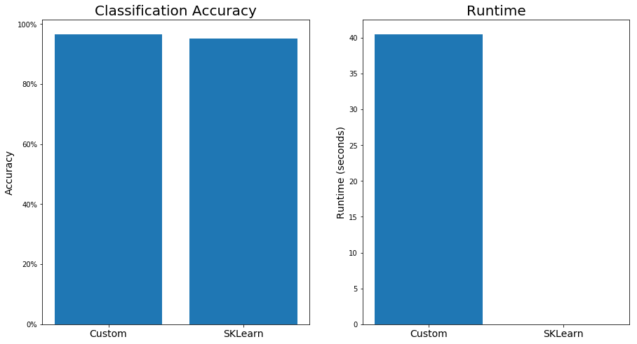

```python
# some visualization
import matplotlib.ticker as mtick

plt.subplots(figsize=(15,8))
ax = plt.subplot(1,2,1)
plt.bar([0, 1], [accuracy_score(y_test, yhat), accuracy_score(y_test, yhat_sk)])
plt.xticks([0, 1], ['Custom', 'SKLearn'], fontsize=14)
plt.ylabel('Accuracy', fontsize=14)
plt.title('Classification Accuracy', fontsize=20)
ax.yaxis.set_major_formatter(mtick.PercentFormatter(1.0))

plt.subplot(1,2,2)
plt.bar([0, 1], [runtime, sk_runtime])
plt.xticks([0, 1], ['Custom', 'SKLearn'], fontsize=14)
plt.ylabel('Runtime (seconds)', fontsize=14)
plt.title('Runtime', fontsize=20)

plt.show()
```

## 3. Deployment

If this model were to be used in a deployed scenario, we would recommend that Scikit-Learn's implementation be used. While the performance of our implementation and Scikit-Learn's implementation are comparable, Scikit-Learn's implementation takes a signficantly shorter time to fit. In Section 1, we suggested that training time should not be optimized as the model would be best used in an offline implementation, however for a deployed implementation training time is more important and should be optimized to reduce delays in obtaining up-to-date results.

## 4. Optimization for Logistic Regression using Mean-Squared-Error

In this section, logistic regression will be implemented using mean-squared-error (MSE) as the objective function. The objective function is thus

$$ l(\mathbf{w}) = \frac{1}{2N} \sum_{i=1}^N \left(y^{(i)} - \widehat{y}^{(i)}\right)^2 = \frac{1}{2N} \sum_{i=1}^N \left(y^{(i)} - g(\mathbf{w}^T \mathbf{x}^{(i)})\right)^2 $$

where $g(\mathbf{w}^T \mathbf{x}^{(i)})$ is the logistic function, given by

$$ g(\mathbf{w}^T \mathbf{x}^{(i)}) = \frac{1}{1 + e^{-\mathbf{w}^T \mathbf{x}^{(i)}}} $$

The Newton update equation is given by

$$ \mathbf{w} \leftarrow \mathbf{w} + \eta \cdot \underbrace{\mathbf{H}[l(\mathbf{w})]^{-1}}_{\text{inverse Hessian}}\cdot\underbrace{\nabla l(\mathbf{w})}_{\text{gradient}} $$

In order to use this equation, we must solve for the Hessian matrix $\mathbf{H}[l(\mathbf{w})]$ using mean-squared-error as the objective function $l(\mathbf{w})$.

The general equation for the Hessian matrix is

$$ \mathbf{H}[l(\mathbf{w})] = \nabla^2 l(\mathbf{w}) = \frac{\partial^2}{\partial w_j \partial w_k} l(\mathbf{w}) $$

The first derivative of the objective function $l(\mathbf{w})$ is

$$ \frac{\partial}{\partial w_j} l(\mathbf{w}) = -\frac{1}{N} \sum_{i=1}^N \left(y^{(i)} - g(\mathbf{w}^T \mathbf{x}^{(i)})\right) \frac{\partial g(\mathbf{w}^T \mathbf{x}^{(i)})}{\partial w_j} $$

where

$$ \frac{\partial g(\mathbf{w}^T \mathbf{x}^{(i)})}{\partial w_j} = \left(1 - g(\mathbf{w}^T \mathbf{x}^{(i)})\right) g(\mathbf{w}^T \mathbf{x}^{(i)}) x_j^{(i)} $$

Substituting this in, the first derivative of $l(\mathbf{w})$ becomes

$$ \frac{\partial}{\partial w_j} l(\mathbf{w}) = -\frac{1}{N} \sum_{i=1}^N \left(y^{(i)} - g(\mathbf{w}^T \mathbf{x}^{(i)})\right) \left(1 - g(\mathbf{w}^T \mathbf{x}^{(i)})\right) g(\mathbf{w}^T \mathbf{x}^{(i)}) x_j^{(i)} = -\frac{1}{N} \sum_{i=1}^N \left[g(\mathbf{w}^T \mathbf{x}^{(i)})^3 - g(\mathbf{w}^T \mathbf{x}^{(i)})^2 \left(y^{(i)} + 1\right) + g(\mathbf{w}^T \mathbf{x}^{(i)}) y^{(i)}\right] x_j^{(i)} $$

Now, taking the partial derivative of this with respect to $w_k$ gives

$$ \mathbf{H}_{j,k}[l(\mathbf{w})] = \frac{\partial}{\partial w_j \partial w_k} l(\mathbf{w}) = -\frac{1}{N} \sum_{i=1}^N \left[3 g(\mathbf{w}^T \mathbf{x}^{(i)})^2 - 2 g(\mathbf{w}^T \mathbf{x}^{(i)}) \left(y^{(i)} + 1\right) + y^{(i)}\right] \left(1 - g(\mathbf{w}^T \mathbf{x}^{(i)})\right) g(\mathbf{w}^T \mathbf{x}^{(i)}) x_j^{(i)} x_k^{(i)} $$

as the Hessian using mean-squared-error as the objective function. Rewriting in linear algebra form yields

$$ \mathbf{H}[l(\mathbf{w})] = \mathbf{X}^T \cdot \text{diag} \left[ \left[3 g(\mathbf{X} \cdot \mathbf{w})^2 - 2 g(\mathbf{X} \cdot \mathbf{w}) \left(\mathbf{y} + 1\right) + \mathbf{y}\right] \left(1 - g(\mathbf{X} \cdot \mathbf{w})\right) g(\mathbf{X} \cdot \mathbf{w}) \right] \cdot \mathbf{X} - 2C $$

where $2C$ is the regularization for the Hessian matrix. Note that the constant coefficient ($\frac{1}{N}$) has been removed as it has no effect on the final solution.

The gradient for the objective function is given by

$$ \nabla l(\mathbf{w}) = \sum_{i=1}^N \left(y^{(i)} - g(\mathbf{w}^T \mathbf{x}^{(i)}) \right) \mathbf{x}^{(i)} = \mathbf{X} * \left(\mathbf{y} - g(\mathbf{X} \cdot \mathbf{w}) \right) $$

Inserting the equations for $\mathbf{H}[l(\mathbf{w})]$ and $\nabla l(\mathbf{w})$ into the Newton update equation gives

$$ \mathbf{w} \leftarrow \mathbf{w} + \eta \cdot \left[ \mathbf{X}^T \cdot \text{diag} \left[ \left[3 g(\mathbf{X} \cdot \mathbf{w})^2 - 2 g(\mathbf{X} \cdot \mathbf{w}) \left(\mathbf{y} + 1\right) + \mathbf{y}\right] \left(1 - g(\mathbf{X} \cdot \mathbf{w})\right) g(\mathbf{X} \cdot \mathbf{w}) \right] \cdot \mathbf{X} - 2C\right]^{-1} \cdot \mathbf{X} * \left(\mathbf{y} - g(\mathbf{X} \cdot \mathbf{w}) \right) $$

This equation is implemented below as an extension of the logistic regression implementation created previously.

```python
class HessianBinaryLogisticRegressionMSE(BinaryLogisticRegression):
    def _get_gradient(self, X, y):
        g = self.predict_proba(X, add_bias=False).ravel()
        hessian = X.T @ np.diag((3*(g**2) - 2*g*(y+1) + y)*(1 - g)*g) @ X - 2*self.C # calculate the Hessian
        ydiff = y - g # get y difference
        gradient = np.sum(X * self.predict_proba(X, add_bias=False) * ydiff[:,np.newaxis], axis=0)
        gradient = gradient.reshape(self.w_.shape)

        if self.reg == "L2":
            gradient[1:] += -2 * self.w_[1:] * self.C
        elif self.reg == "L1":
            gradient[1:] += -1 * np.sign(self.w_[1:]) * self.C
        elif self.reg == "ElasticNet":
            gradient[1:] += -self.C * ((2*self.w_[1:]) + (np.sign(self.w_[1:])) )

        return pinv(hessian) @ gradient
```

This method of using Newton's method with an MSE objective function may be problematic for a couple of reasons:

1. Newton's method is sensitive to the initialization point (weights)
2. The MSE objective function is non-convex and may lead to Newton's method converging to a non-optimal solution

An option to initialize the weights as random numbers, rather than zeros, was added to the `BinaryLogisticRegression` class above. To investigate the performance of Newton's method using MSE as the objective function with only a single gradient update step, 1000 estimators will be fit and their performance calculated.

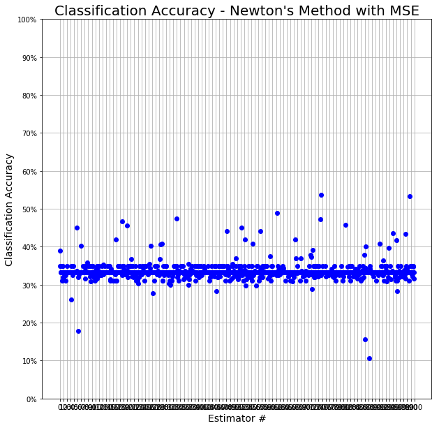

```python
n_iters = 1000
score = np.zeros((n_iters,1))

for i in range(n_iters):
    hlr = LogisticRegression(eta=0.1, iterations=1, C=0.01, solver='NewtonMSE', regularization='L2', w0='random')
    hlr.fit(X_train,y_train)
    yhat = hlr.predict(X_test)
    score[i] = accuracy_score(y_test, yhat)

fig, ax = plt.subplots(figsize=(10,10))
plt.plot(range(n_iters), score, 'bo')
plt.title("Classification Accuracy - Newton's Method with MSE", fontsize=20)
plt.xlabel('Estimator #', fontsize=14)
plt.ylabel('Classification Accuracy', fontsize=14)
plt.xticks(np.linspace(0.0, n_iters, n_iters/10+1))
plt.yticks(np.linspace(0.0, 1.0, 11.0))
ax.yaxis.set_major_formatter(mtick.PercentFormatter(1.0))
plt.grid()
plt.show()
```

## References

1. Chawla, N. V., Bowyer, K. W., Hall, L. O., and Kegelmeyer, W. P. (2002). "SMOTE: Synthetic Minority Over-sampling Technique." *Journal of Artificial Intelligence*, 16, 321-357.